# Détection de spams

Kezhan SHI

21 novembre 2015

# 1 Introduction

Quelques algorithmes de machine learning sont illustrés pour la problématique de détecter de spams.

La base de données initiale doit être un ensemble de mails. Le text-mining permet ensuite de nettoyer les textes afin de construire une matrix de caractéristiques. Les caractéristiques peuvent être de plusieurs types :

- Fréquences de certains mots
- Fréquences de certains caractères spéciaux
- Fréquences de lettre en capital, pour notamment détecter si le mail est écrit tout en majuscule
- Répétition de lettre dans un mot (comme merciiiiiiiii)

Concernant les mails, on peut également construire d’autres caractéristiques :

- Adresse mail de l’expéditeur : la composition de l’adresse, le nom de domaine, etc.
- Heure d’envoi du mail
- Destinataire : le nombre de destinataire, destination principale ou en copie
- Titre du mail
- Signature
- Images

La construction de la matrice de caractéristiques est souvent appelé *feature engineering* en anglais. C’est une étape primordiale. Ici, nous allons utiliser une base de données connue en data-mining : spambase de George Forman, construit sur un ensemble de mails reçus chez Hewlett-Packard Labs.

# 2 Exploration de la base de données

On peut télécharger la base de données sur le site de [UC Irvine Machine Learning Repository](https://archive.ics.uci.edu/ml/datasets/Spambase).

```r
data=read.table("spambase.data",header=F,sep=",")
names=read.csv2("names.csv",header=F)
names
```

```
##                            V1
## 1              word_freq_make
## 2           word_freq_address
## 3               word_freq_all
## 4                word_freq_3d
## 5               word_freq_our
## 6              word_freq_over
## 7            word_freq_remove
## 8          word_freq_internet
## 9             word_freq_order
## 10             word_freq_mail
## 11          word_freq_receive
## 12             word_freq_will
## 13           word_freq_people
## 14           word_freq_report
```

[output cut: 43 more lines]

```r
colnames(data)=c(as.character(names[,1]),"class")
dim(data)
```

```
## [1] 4601   58
```

```r
data$class=as.factor(as.character(data$class))

table(data$class)
```

```
##
##    0    1
## 2788 1813
```

# 3 Construction des modèles

## 3.1 Base d’apprentissage

```r
ind=createDataPartition(data$class, times = 1,p = 0.3,list=FALSE)
a=data[ind,]
t=data[-ind,]
dim(a);dim(t)
```

```
## [1] 1381   58
```

```
## [1] 3220   58
```

## 3.2 Arbres de classification

### 3.2.1 Apprentissage de l’arbre de décision

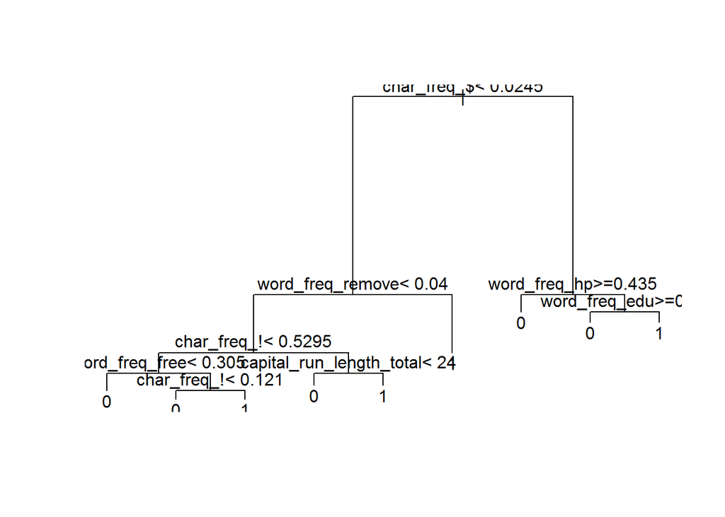

```r
formula=as.formula(class ~.)

fit.ct <- rpart(formula, a, method = "class")

# On affiche l'arbre
plot(fit.ct)
# On affiche l'arbre avec les valeurs
text(fit.ct)
```

Pour afficher un arbre plus esthétique :

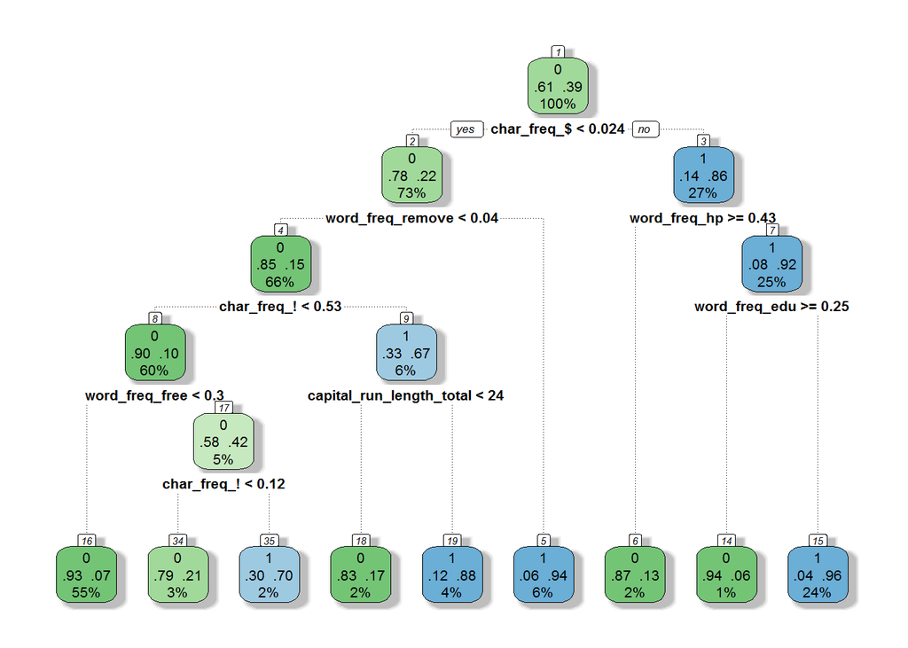

```r
fancyRpartPlot(fit.ct,main="",sub="")
```

### 3.2.2 Matrice de confusion

```r
mc.ct.a=confusionMatrix(predict(fit.ct,type="class"),a$class)
mc.ct.t=confusionMatrix(predict(fit.ct,newdata=t,type="class"),t$class)
mc.ct.a
```

```
## Confusion Matrix and Statistics
##
##           Reference
## Prediction   0   1
##          0 804  70
##          1  33 474
##
##                Accuracy : 0.9254
##                  95% CI : (0.9103, 0.9387)
##     No Information Rate : 0.6061
##     P-Value [Acc > NIR] : < 2.2e-16
##
##                   Kappa : 0.8419
##  Mcnemar's Test P-Value : 0.0003894
##
##             Sensitivity : 0.9606
##             Specificity : 0.8713
##          Pos Pred Value : 0.9199
##          Neg Pred Value : 0.9349
##              Prevalence : 0.6061
##          Detection Rate : 0.5822
##    Detection Prevalence : 0.6329
##       Balanced Accuracy : 0.9159
##
##        'Positive' Class : 0
##
```

```r
mc.ct.t
```

```
## Confusion Matrix and Statistics
##
##           Reference
## Prediction    0    1
##          0 1822  196
##          1  129 1073
##
##                Accuracy : 0.8991
##                  95% CI : (0.8881, 0.9093)
##     No Information Rate : 0.6059
##     P-Value [Acc > NIR] : < 2.2e-16
##
##                   Kappa : 0.7867
##  Mcnemar's Test P-Value : 0.0002512
##
##             Sensitivity : 0.9339
##             Specificity : 0.8455
##          Pos Pred Value : 0.9029
##          Neg Pred Value : 0.8927
##              Prevalence : 0.6059
##          Detection Rate : 0.5658
##    Detection Prevalence : 0.6267
##       Balanced Accuracy : 0.8897
##
##        'Positive' Class : 0
##
```

### 3.2.3 Prédiction des résultats en terme de probabilité

```r
head(predict(fit.ct,type="prob"))
```

```
##             0         1
## 3  0.03636364 0.9636364
## 9  0.03636364 0.9636364
## 11 0.05617978 0.9438202
## 12 0.05617978 0.9438202
## 15 0.30000000 0.7000000
## 18 0.03636364 0.9636364
```

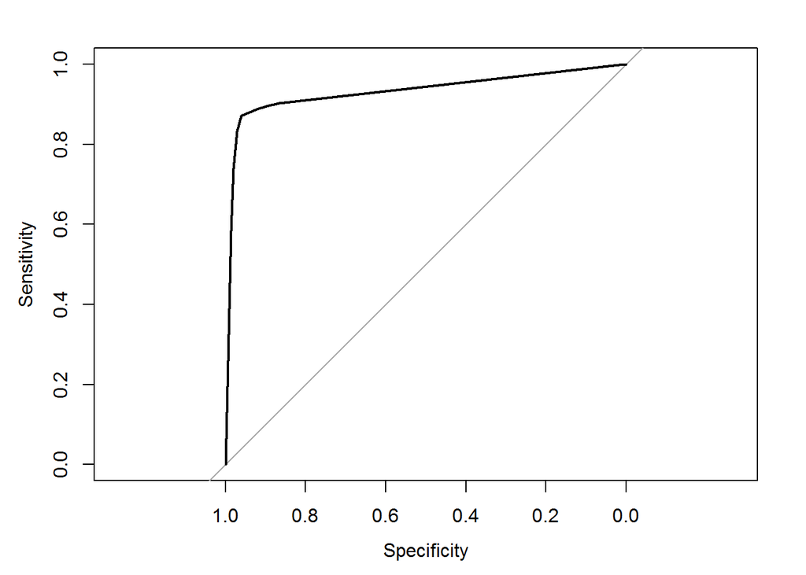

```
##
## Call:
## roc.default(response = a$class, predictor = predict(fit.ct, data = a,     type = "prob")[, 1])
##
## Data: predict(fit.ct, data = a, type = "prob")[, 1] in 837 controls (a$class 0) > 544 cases (a$class 1).
## Area under the curve: 0.9319
```

```r
roc.ct=roc(a$class,predict(fit.ct,data=a,type="prob")[,1])
plot(roc.ct)
```

### 3.2.4 Optimisation

Si on réduit la profondeur de l’arbre à 2 :

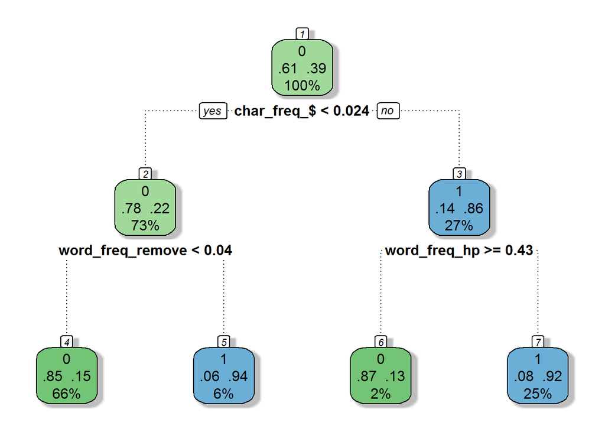

```r
fit.ct=rpart(formula,a,method = "class",
             control=rpart.control(maxdepth = 2))
fancyRpartPlot(fit.ct,main="",sub="")
```

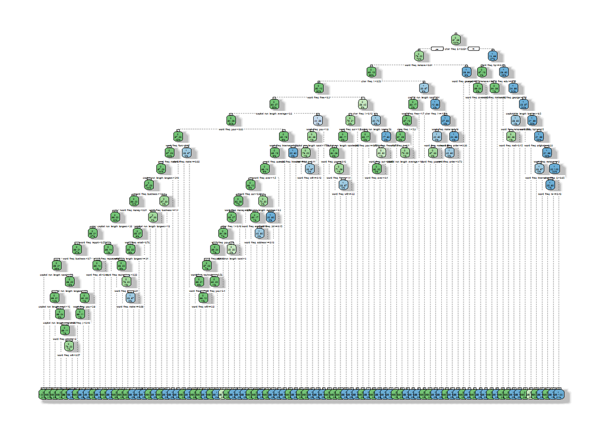

```r
fit.ct=rpart(formula,a,method = "class",
              control=rpart.control(minsplit=3, cp=0.000))
fancyRpartPlot(fit.ct,main="",sub="")
```

```r
#summary(fit.ct)
printcp(fit.ct)
```

```
##
## Classification tree:
## rpart(formula = formula, data = a, method = "class", control = rpart.control(minsplit = 3,
##     cp = 0))
##
## Variables actually used in tree construction:
##  [1] capital_run_length_average capital_run_length_longest
##  [3] capital_run_length_total   char_freq_!
##  [5] char_freq_$                char_freq_(
##  [7] word_freq_3d               word_freq_address
##  [9] word_freq_all              word_freq_business
## [11] word_freq_edu              word_freq_email
## [13] word_freq_font             word_freq_free
## [15] word_freq_george           word_freq_hp
## [17] word_freq_hpl              word_freq_internet
```

[output cut: 35 more lines]

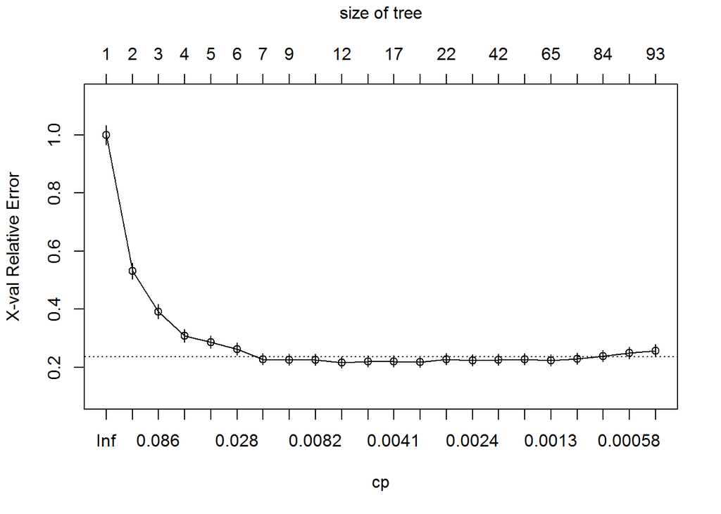

```r
plotcp(fit.ct)
```

## 3.3 SVM

### 3.3.1 Apprentissage

```r
library(kernlab)
fit.svm=ksvm(class~.,a)
```

### 3.3.2 Prédictions

```r
mc.svm.a=confusionMatrix(predict(fit.svm,type="response"),a$class)
mc.svm.t=confusionMatrix(predict(fit.svm,newdata=t,type="response"),t$class)

mc.svm.a
```

```
## Confusion Matrix and Statistics
##
##           Reference
## Prediction   0   1
##          0 817  40
##          1  20 504
##
##                Accuracy : 0.9566
##                  95% CI : (0.9444, 0.9667)
##     No Information Rate : 0.6061
##     P-Value [Acc > NIR] : < 2e-16
##
##                   Kappa : 0.9084
##  Mcnemar's Test P-Value : 0.01417
##
##             Sensitivity : 0.9761
##             Specificity : 0.9265
##          Pos Pred Value : 0.9533
##          Neg Pred Value : 0.9618
##              Prevalence : 0.6061
##          Detection Rate : 0.5916
##    Detection Prevalence : 0.6206
##       Balanced Accuracy : 0.9513
##
##        'Positive' Class : 0
##
```

```r
mc.svm.t
```

```
## Confusion Matrix and Statistics
##
##           Reference
## Prediction    0    1
##          0 1862  195
##          1   89 1074
##
##                Accuracy : 0.9118
##                  95% CI : (0.9015, 0.9214)
##     No Information Rate : 0.6059
##     P-Value [Acc > NIR] : < 2.2e-16
##
##                   Kappa : 0.8126
##  Mcnemar's Test P-Value : 4.646e-10
##
##             Sensitivity : 0.9544
##             Specificity : 0.8463
##          Pos Pred Value : 0.9052
##          Neg Pred Value : 0.9235
##              Prevalence : 0.6059
##          Detection Rate : 0.5783
##    Detection Prevalence : 0.6388
##       Balanced Accuracy : 0.9004
##
##        'Positive' Class : 0
##
```

## 3.4 Regression Logistique

### 3.4.1 Apprentissage

```r
fit.glm=glm(class~.,family=binomial(link="logit"),a)
summary(fit.glm)
```

```
##
## Call:
## glm(formula = class ~ ., family = binomial(link = "logit"), data = a)
##
## Deviance Residuals:
##     Min       1Q   Median       3Q      Max
## -4.2479  -0.1588   0.0000   0.0555   3.2329
##
## Coefficients:
##                              Estimate Std. Error z value Pr(>|z|)
## (Intercept)                -2.828e+00  3.826e-01  -7.391 1.46e-13 ***
## word_freq_make             -1.221e+00  4.933e-01  -2.475 0.013311 *
## word_freq_address          -1.128e-01  1.041e-01  -1.084 0.278556
## word_freq_all               2.193e-01  1.963e-01   1.117 0.263954
## word_freq_3d                8.944e-01  1.591e+00   0.562 0.574078
## word_freq_our               6.929e-01  1.924e-01   3.602 0.000316 ***
## word_freq_over              6.570e-01  4.001e-01   1.642 0.100544
## word_freq_remove            2.727e+00  7.638e-01   3.570 0.000357 ***
## word_freq_internet          2.485e-01  2.375e-01   1.046 0.295416
## word_freq_order             3.599e-02  4.843e-01   0.074 0.940750
## word_freq_mail              1.941e-01  1.692e-01   1.147 0.251480
## word_freq_receive          -2.518e-01  5.313e-01  -0.474 0.635561
## word_freq_will             -1.833e-01  1.573e-01  -1.165 0.243867
## word_freq_people           -3.623e-01  5.201e-01  -0.697 0.486067
## word_freq_report            1.060e+00  4.251e-01   2.494 0.012626 *
## word_freq_addresses         9.423e-01  1.167e+00   0.808 0.419290
## word_freq_free              7.778e-01  2.492e-01   3.121 0.001800 **
## word_freq_business          1.129e+00  4.618e-01   2.444 0.014520 *
## word_freq_email             1.028e-01  2.706e-01   0.380 0.703987
## word_freq_you               1.424e-01  6.558e-02   2.171 0.029911 *
## word_freq_credit            1.736e+00  1.039e+00   1.671 0.094781 .
## word_freq_your              2.553e-01  1.024e-01   2.494 0.012639 *
## word_freq_font              6.204e-01  7.083e-01   0.876 0.381149
## word_freq_000               4.204e+00  1.466e+00   2.867 0.004138 **
## word_freq_money             2.972e-01  2.054e-01   1.447 0.147841
## word_freq_hp               -1.735e+00  5.536e-01  -3.134 0.001722 **
## word_freq_hpl              -2.260e-01  5.511e-01  -0.410 0.681752
## word_freq_george           -1.702e+01  5.374e+00  -3.167 0.001541 **
## word_freq_650               1.227e-01  3.699e-01   0.332 0.740156
## word_freq_lab              -4.976e-01  1.944e+00  -0.256 0.797951
```

[output cut: 23 more lines]

```
## `char_freq_$`               4.882e+00  1.328e+00   3.675 0.000238 ***
## `char_freq_#`               2.977e+00  1.885e+00   1.580 0.114167
## capital_run_length_average  5.235e-01  1.189e-01   4.403 1.07e-05 ***
## capital_run_length_longest -2.630e-03  5.751e-03  -0.457 0.647419
## capital_run_length_total    2.206e-03  5.473e-04   4.031 5.55e-05 ***
## ---
## Signif. codes:  0 '***' 0.001 '**' 0.01 '*' 0.05 '.' 0.1 ' ' 1
##
## (Dispersion parameter for binomial family taken to be 1)
##
##     Null deviance: 1851.83  on 1380  degrees of freedom
## Residual deviance:  472.11  on 1323  degrees of freedom
## AIC: 588.11
##
## Number of Fisher Scoring iterations: 22
```

### 3.4.2 Prédictions

```r
mc.glm.a=confusionMatrix(
  ifelse(predict(fit.glm,type="response")>0.5,1,0),
  a$class)
mc.glm.t=confusionMatrix(
  ifelse(predict(fit.glm,newdata=t,type="response")>0.5,1,0),
  t$class)

mc.glm.a
```

```
## Confusion Matrix and Statistics
##
##           Reference
## Prediction   0   1
##          0 797  48
##          1  40 496
##
##                Accuracy : 0.9363
##                  95% CI : (0.9221, 0.9486)
##     No Information Rate : 0.6061
##     P-Value [Acc > NIR] : <2e-16
##
##                   Kappa : 0.8662
##  Mcnemar's Test P-Value : 0.4555
##
##             Sensitivity : 0.9522
##             Specificity : 0.9118
##          Pos Pred Value : 0.9432
##          Neg Pred Value : 0.9254
##              Prevalence : 0.6061
##          Detection Rate : 0.5771
##    Detection Prevalence : 0.6119
##       Balanced Accuracy : 0.9320
##
##        'Positive' Class : 0
##
```

```r
mc.glm.t
```

```
## Confusion Matrix and Statistics
##
##           Reference
## Prediction    0    1
##          0 1855  155
##          1   96 1114
##
##                Accuracy : 0.922
##                  95% CI : (0.9122, 0.9311)
##     No Information Rate : 0.6059
##     P-Value [Acc > NIR] : < 2.2e-16
##
##                   Kappa : 0.8354
##  Mcnemar's Test P-Value : 0.0002513
##
##             Sensitivity : 0.9508
##             Specificity : 0.8779
##          Pos Pred Value : 0.9229
##          Neg Pred Value : 0.9207
##              Prevalence : 0.6059
##          Detection Rate : 0.5761
##    Detection Prevalence : 0.6242
##       Balanced Accuracy : 0.9143
##
##        'Positive' Class : 0
##
```

## 3.5 Analyse Discriminante

```r
fit.lda=lda(class~.,data=a)
```

```r
mc.lda.a=confusionMatrix(predict(fit.lda,data=a)$class,a$class)
mc.lda.t=confusionMatrix(predict(fit.lda,newdata=t)$class,t$class)
```

# 4 Synthèse des modèles

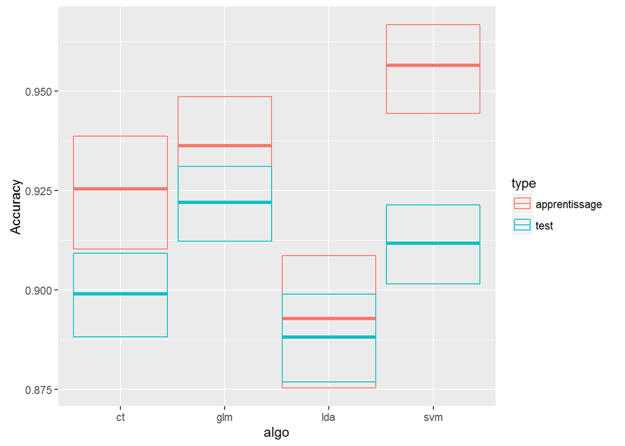

```r
df=as.data.frame(rbind(c("ct","apprentissage",mc.ct.a$overall[c("AccuracyLower","Accuracy","AccuracyUpper")]),
c("ct","test",mc.ct.t$overall[c("AccuracyLower","Accuracy","AccuracyUpper")]),

c("svm","apprentissage",mc.svm.a$overall[c("AccuracyLower","Accuracy","AccuracyUpper")]),
c("svm","test",mc.svm.t$overall[c("AccuracyLower","Accuracy","AccuracyUpper")]),

c("glm","apprentissage",mc.glm.a$overall[c("AccuracyLower","Accuracy","AccuracyUpper")]),
c("glm","test",mc.glm.t$overall[c("AccuracyLower","Accuracy","AccuracyUpper")]),

c("lda","apprentissage",mc.lda.a$overall[c("AccuracyLower","Accuracy","AccuracyUpper")]),
c("lda","test",mc.lda.t$overall[c("AccuracyLower","Accuracy","AccuracyUpper")])))

colnames(df)[1:2]=c("algo","type")
df[,"AccuracyLower"]=as.numeric(as.character(df[,"AccuracyLower"]))
df[,"Accuracy"]=as.numeric(as.character(df[,"Accuracy"]))
df[,"AccuracyUpper"]=as.numeric(as.character(df[,"AccuracyUpper"]))

p <- ggplot(df, aes(algo, Accuracy, colour = type))
p + geom_crossbar(aes(ymin = AccuracyLower, ymax = AccuracyUpper))
```

# 5 Agrégation de modèles

## 5.1 Bagging

```r
fit.bag=bagging(class ~.,a,nbagg=60)
mc.bag.a=confusionMatrix(predict(fit.bag,data=a),a$class)
mc.bag.t=confusionMatrix(predict(fit.bag,newdata=t),t$class)
```

## 5.2 Foret Aleatoire

```r
colnames(a)[49:54]=paste0("v_",seq(1:6))
colnames(t)[49:54]=paste0("v_",seq(1:6))

fit.rf=randomForest(class~.,data=a)

mc.rf.a=confusionMatrix(predict(fit.rf,data=a,type="class"),a$class)
mc.rf.t=confusionMatrix(predict(fit.rf,newdata=t,type="class"),t$class)
```

# 6 Synthèse Finale

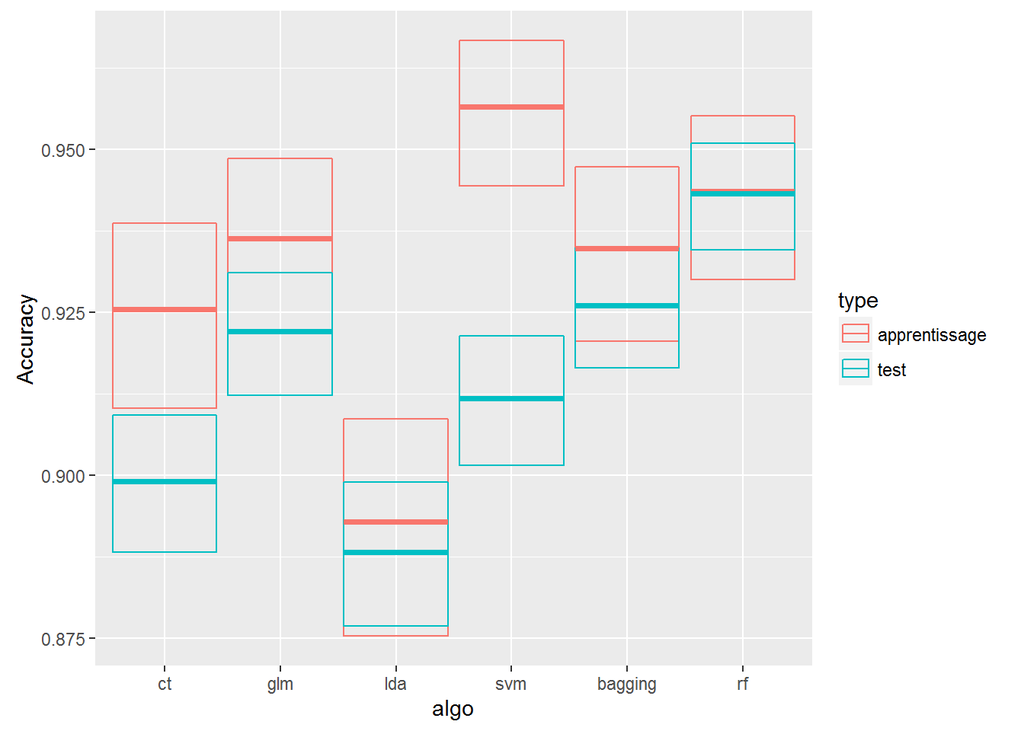

```r
df2=as.data.frame(rbind(c("bagging","apprentissage",mc.bag.a$overall[c("AccuracyLower","Accuracy","AccuracyUpper")]),
c("bagging","test",mc.bag.t$overall[c("AccuracyLower","Accuracy","AccuracyUpper")]),

c("rf","apprentissage",mc.rf.a$overall[c("AccuracyLower","Accuracy","AccuracyUpper")]),
c("rf","test",mc.rf.t$overall[c("AccuracyLower","Accuracy","AccuracyUpper")])))

df2[,"AccuracyLower"]=as.numeric(as.character(df2[,"AccuracyLower"]))
df2[,"Accuracy"]=as.numeric(as.character(df2[,"Accuracy"]))
df2[,"AccuracyUpper"]=as.numeric(as.character(df2[,"AccuracyUpper"]))

colnames(df2)[1:2]=c("algo","type")

p <- ggplot(rbind(df,df2), aes(algo, Accuracy, colour = type))
p + geom_crossbar(aes(ymin = AccuracyLower, ymax = AccuracyUpper))
```